# Quantitative Spatial Economics

## Tutorial Topic 1: Rosen-Roback

Humboldt University Berlin & Berlin School of Economics

Authors: Dominik Bursy, Lars Felder, Marlon Krippendorf

Last Update: April 2024

In Topic 1, we covered the Rosen-Roback framework during the lecture. In this tutorial, we apply the logic of the spatial equilibrium framework to compute a quality-of- life (QoL) ranking for Germany counties (Kreise & kreisfreie Städte).

## Task 1: Wage and Employment across Germany

### Descriptive Statistics Employment across Germany

```
| Workers   |   No Qualification |   Professional |   Academic |
|-----------+--------------------+----------------+------------|
| count     |             400    |          400   |      400   |
| mean      |            4651.64 |        34476.9 |    11531.5 |
| std       |            6485.95 |        39289.4 |    29205.1 |
| min       |             354    |         5092   |      641   |
| 25%       |            1732.75 |        16472   |     2690   |
| 50%       |            2848    |        24859   |     4755.5 |
| 75%       |            5459.5  |        38817.8 |     9950.5 |
| max       |           73456    |       475713   |   360929   |
```

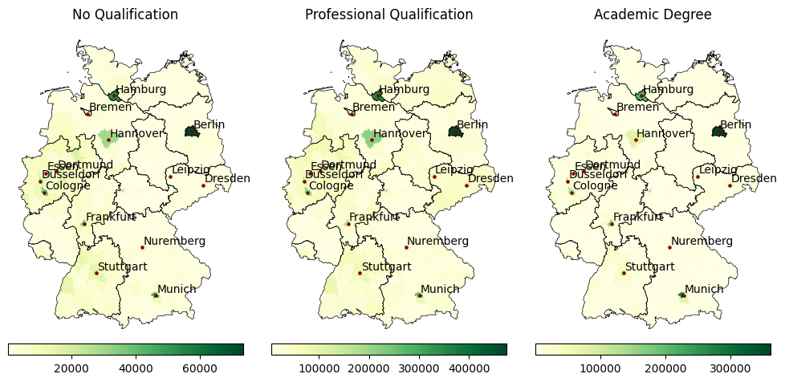

### Descriptive Statistics Wages across Germany

```
| Wages   |   No Qualification |   Professional |   Academic |
|---------+--------------------+----------------+------------|
| count   |            396     |        400     |    400     |
| mean    |           2627.04  |       3436.1   |   5178.3   |
| std     |            238.413 |        377.625 |    581.128 |
| min     |           2145.27  |       2576.14  |   4044.25  |
| 25%     |           2470.09  |       3254.59  |   4736.78  |
| 50%     |           2635.93  |       3460.88  |   5089.03  |
| 75%     |           2776.48  |       3648.54  |   5469.77  |
| max     |           3378.25  |       4908.91  |   7050     |
```

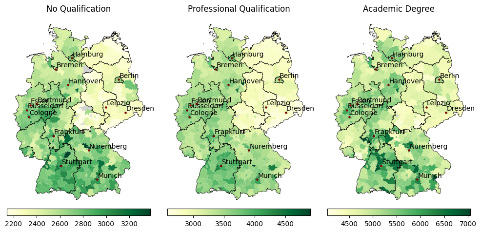

## Task 2: Mix-Adjusted House Price Index

The standard way of creating a mix-adjusted price index is to adjust for observable characteristics in an “hedonic” regressions and recover fixed effects for the spatial units of interest:

$$ price_{ic} = \beta_1 + \beta_2 constructionyear_{ic} + \beta_3 floor_{ic} + \beta_4 rooms_{ic} + \beta_5 kitchen_{ic} + \beta_6 parking_{ic} + \beta_7 elevator_{ic} + \gamma_{c} + \epsilon_{ic} $$

### Rent Price Index

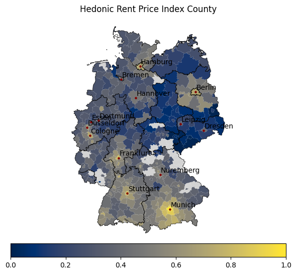

### Purchase Price Index

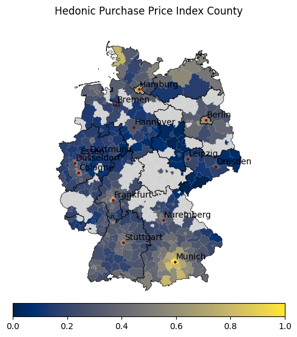

## Task 3: Exogenous Factors

Following the quantitative spatial equilibrium framework by Glaeser & Gottlieb (2009) we derive the exogenous factors for amenities $B_c$, productivities $A_c$, and land availability $M_c$ using the equilibrium conditions:

$$ log(w_c) = \Omega_1 + \frac{log(A_c)}{1−\beta} − \frac{1−\alpha−\beta}{1−\beta} log(L_c) + \frac{1−\alpha−\beta}{1−\beta} log(Z) $$

$$ log(P_c) = \Omega_2 + \frac{\delta - 1}{\delta} [log(w_c) + log(L_c) − log(M_c)] $$

$$ log(w_c) = \Omega_3 - log(B_c) + \sigma log(P_c) $$

Since $\Omega_1$, $\Omega_2$, and $\Omega_3$ are constant values that do not vary on the county level, we set them equal to zero.

### (a) Quality-of-Life Index

Since we assume the expenditure share of housing $\sigma$ is one-third, we can solve the indifference condition for $B_c$:

|  | No Qualification (Rent) | Professional (Rent) | Academic (Rent) |
| --- | --- | --- | --- |
| 0 | Potsdam | Dahme-Spreewald | Garmisch-Partenkirchen |
| 1 | Dahme-Spreewald | Potsdam-Mittelmark | Dahme-Spreewald |
| 2 | Garmisch-Partenkirchen | Havelland | Havelland |
| 3 | Dachau | Märkisch-Oderland | Märkisch-Oderland |
| 4 | Potsdam-Mittelmark | Oberhavel | Aichach-Friedberg |
| 5 | Teltow-Fläming | Barnim | Ebersberg |
| 6 | Rosenheim | Miesbach | Barnim |
| 7 | Oberhavel | Garmisch-Partenkirchen | Freiburg im Breisgau |
| 8 | Ebersberg | Potsdam | Potsdam |
| 9 | Offenbach am Main | Ostholstein | Dachau |

|  | No Qualification (Purchase) | Professional (Purchase) | Academic (Purchase) |
| --- | --- | --- | --- |
| 0 | Vorpommern-Rügen | Rostock | Wittmund |
| 1 | Garmisch-Partenkirchen | Vorpommern-Rügen | Schwabach |
| 2 | Nordfriesland | Nordfriesland | Neustadt an der Weinstraße |
| 3 | Vorpommern-Greifswald | Vorpommern-Greifswald | Kaufbeuren |
| 4 | Rostock | Garmisch-Partenkirchen | Bayreuth |
| 5 | Potsdam | Miesbach | Fürth |
| 6 | Dachau | Ostholstein | Delmenhorst |
| 7 | Ebersberg | Potsdam | Plön |
| 8 | Rosenheim | Nordwestmecklenburg | Friesland |
| 9 | Miesbach | Dachau | Garmisch-Partenkirchen |

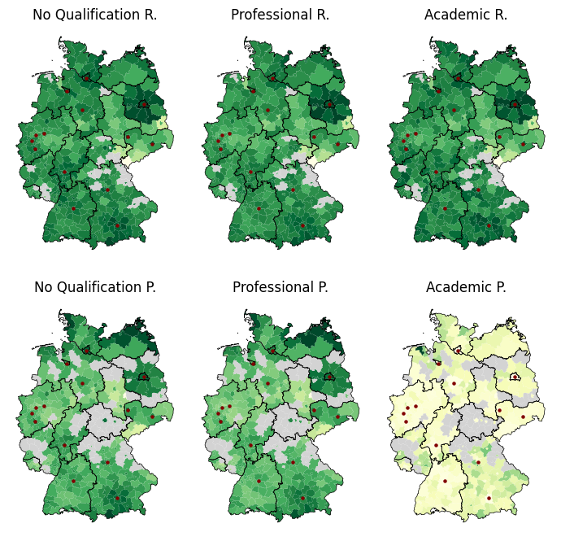

After plotting, here’s what we find:

- Quality of Life in capital cities is high across skill groups and price indices
- Alpine region is really popular as well as Northern Germany boarding the Nordic and the Baltic Sea
- Though workers with a academic degree are less favorable in buying property within cities and rather settle in the suburbs
- Also people who rent value have an increased valuation of the France and Swiss boarder region

### (b) Fundamental productivity

Since we assume the expenditure share of labour $\alpha$ is two-thirds, we can rearrange the general equilibrium condition wrt $A_c$:

$$ log(L_c) = \Omega_1 \frac{1−\beta}{1−\alpha−\beta} + log(\overline{Z}) - \frac{1−\beta}{1−\alpha−\beta} log(w_c) + \frac{1}{1−\alpha−\beta} log(A_c) $$

Calculate the share of capital by estimating and rearranging the coefficient:

$$ \beta = \frac{1 + (1 - \alpha) \eta}{1 + \eta} $$

```
= 0.4410439624209132
```

|  | Productivity Index Top 10 | Productivity Index Bottom 10 |
| --- | --- | --- |
| 0 | Salzgitter | Region Hannover |
| 1 | Frankenthal (Pfalz) | Mittelsachsen |
| 2 | Zweibrücken | Hamburg |
| 3 | Erlangen | Erzgebirgskreis |
| 4 | Ingolstadt | Berlin |
| 5 | Wolfsburg | Lüchow-Dannenberg |
| 6 | Kusel | Suhl |
| 7 | Donnersbergkreis | Weimar |
| 8 | Neustadt an der Weinstraße | Eisenach |
| 9 | Leverkusen | Kyffhäuserkreis |

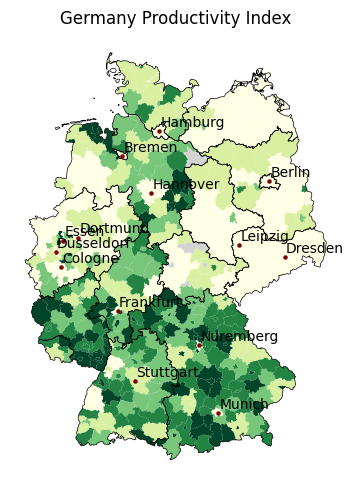

After plotting, here’s what we find:

- Counterintutive pattern, since one would imagine the high productivity in large cities like Munich, Berlin, etc. and in industrial regional like the Ruhr area

### (c) Effective land supply

Since we assume a height elasticity of construction cost $\delta$ of 1.5, we can solve the general equilibrium condition for $M_c$:

$$ log(M_c) = log(w_c) + log(L_c) - \frac{\delta}{\delta-1} [log(P_c) - \Omega_2] \quad \Leftrightarrow \quad M_c = \frac{w_c L_c}{P_c^{\frac{\delta}{\delta-1}}} $$

[output not shown]

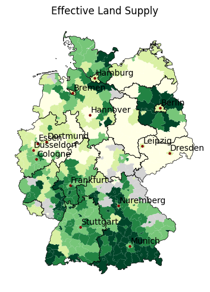

### Alternative Measure of Effective Land Supply

Instead of building height use density (construction costs per square meter):

$$ M_c = \frac{(L_c / Area_c)}{P_c^\epsilon} = \frac{(Density_c)}{P_c^\epsilon} $$

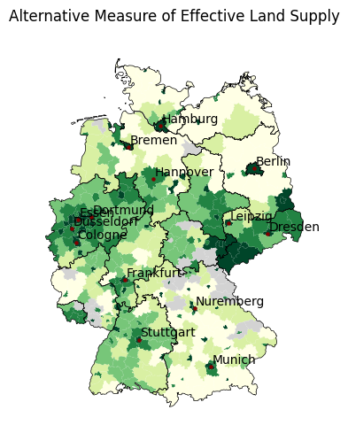

### Bonus Question

Can you think of a theory-consistent way of estimating the height elasticity of construction cost?

If we already solved for $M_c$, we can regress log prices on a composite index of wages, population and land availability which yields the coefficient $\beta = \frac{\delta - 1}{\delta}$. Solving for $\delta$ yields the height elasticity of construction cost.

$$ log(P_c) = \Omega_2 + \frac{\delta - 1}{\delta} [log(w_c) + log(L_c) − log(M_c)] $$

Alternatively, one could use additional information on building heights and run the following regression:

$$ log(D_c) = \underbrace{ - \frac{\delta}{1 - \delta} log(d_0) }_{\text{Constant}} + \underbrace{ \frac{1}{1 - \delta} }_{\text{Elasticity}} log(P_c) $$

Either use rent or purchase index and subsequently solve for $\delta$.